[O’Hara on GitHub](https://github.com/oharac)

# Assign functional entities from gapfilled traits

Compiled on Thu Mar 17 12:53:59 2022 by ohara

```r
knitr::opts_chunk$set(echo = TRUE, message = FALSE, warning = FALSE)

library(oharac)
library(tidyverse)
library(here)
source(here('common_fxns.R'))
```

# 1 Summary

Gather processed and gapfilled traits data. Assign bins for trait values. Use trait bins to identify functional entities (FE) per Villeger and others. Note: reproduction traits, while available, are excluded from assigning the final functional entities.

# 2 Data

Traits from Fishbase/Sealifebase and species vulnerability framework - gapfilled using MICE - from script 1c.

# 3 Methods

## 3.1 Gather traits

Here we will read in the gapfilled traits set and assign the values into specific bins as appropriate. Inspired by Sebastien Villeger’s code, I will create text codes for each trait/value combo, but with a few more letters so they are a little more comprehensible.

### 3.1.1 Set up categories

Adult mobility and water column position are already categorical variables.

- **Adult mobility**: sessile (`ses`), sedentary (`sed`), mobile resident (`mob`), and migratory/nomadic (`mig`)
- **Water column position**: benthic (`ben`), benthopelagic (`bp`), pelagic (`pel`), reef-associated (`rf`)

**Max body length** (cm):

- Very small: (0, 1.5]
- Small: (1.5, 5]
- Medium: (5, 15]
- Large: (15, 100]
- Very large: (100, …)

**Trophic level**:

- Primary consumer: (1, 2]
- Secondary consumer: (2, 3]
- Tertiary consumer: (3, 4]
- Apex consumer: (4, …)

```r
fe_traits <- read_csv(here('_data/grouping_traits_miced_and_gapfilled.csv')) %>%
  mutate(len = exp(log_l),
         # fec = exp(log_f),
         len = case_when(len <= 1.5 ~ 'vsm',
                         len <= 5   ~ 'sm',
                         len <= 15  ~ 'med',
                         len <= 100 ~ 'lg',
                         len > 100  ~ 'vlg',
                         TRUE ~ NA_character_),
         len = factor(len, levels = c('vsm', 'sm', 'med', 'lg', 'vlg'))) %>%
  mutate(trp = case_when(troph <= 2 ~ 'pri',
                         troph <= 3 ~ 'sec',
                         troph <= 4 ~ 'ter',
                         troph > 4  ~ 'apex',
                         TRUE ~ NA_character_),
         trp = factor(trp, levels = c('pri', 'sec', 'ter', 'apex'))) %>%
  select(species, wcol, mob = adult_mob, len,
         # fec, gen,
         trp) %>%
  drop_na()

table(fe_traits$len)
```

```
##
##   vsm    sm   med    lg   vlg
## 38746 36121 26529 18115  1365
```

```r
table(fe_traits$trp)
```

```
##
##   pri   sec   ter  apex
## 18401 33623 64108  4744
```

```r
table(fe_traits$mob)
```

```
##
##   mig   mob   sed   ses
## 14728 46362 30330 29456
```

```r
table(fe_traits$col)
```

```
## < table of extent 0 >
```

## 3.2 Assign to functional entities

Here we will full-join all trait dataframes by species, eliminate any with NA values for any traits, and then collapse the trait values together into a specific functional entity character code (which will also be assigned a numeric FE code).

```r
n_fe_possible <- n_distinct(fe_traits$mob) *
                 # n_distinct(fe_traits$fec) *
                 # n_distinct(fe_traits$gen) *
                 n_distinct(fe_traits$trp) *
                 n_distinct(fe_traits$len) *
                 n_distinct(fe_traits$wcol)
```

Based on the given trait categories, we could see up to 320 functional entities, though most will not be populated (e.g., not so likely to find a very large apex predator species with a high fecundity and short generation time).

[figure not shown]

### 3.2.1 Number of spp included, by phylum/class

```r
worms_spp <- assemble_worms()

incl_spp <- fe_traits %>%
  left_join(worms_spp) %>%
  mutate(gp = ifelse(phylum == 'chordata', paste0('chordata:', class), phylum)) %>%
  group_by(gp) %>%
  summarize(n_spp = n_distinct(species))

knitr::kable(incl_spp)
```

| gp | n_spp |
| --- | --- |
| annelida | 10353 |
| arthropoda | 31813 |
| chordata:actinopterygii | 18560 |
| chordata:aves | 341 |
| chordata:elasmobranchii | 1249 |
| chordata:holocephali | 57 |
| chordata:mammalia | 213 |
| chordata:myxini | 87 |
| chordata:reptilia | 98 |
| cnidaria | 8655 |
| echinodermata | 8991 |
| mollusca | 32976 |
| porifera | 7483 |

### 3.2.2 assign FE codes

```r
fe_df <- fe_traits %>%
  mutate(fe_code = sprintf('MOB%s_TRP%s_LEN%s_WCOL%s', mob, trp, len, wcol)) %>%
  # mutate(fe_code = sprintf('MOB%s_TRP%s_GEN%s_FEC%s_LEN%s_WCOL%s', mob, trp, gen, fec, len, wcol)) %>%
  group_by(fe_code) %>%
  mutate(n = n()) %>%
  ungroup() %>%
  arrange(desc(n)) %>%
  mutate(fe_code = fct_inorder(fe_code))
```

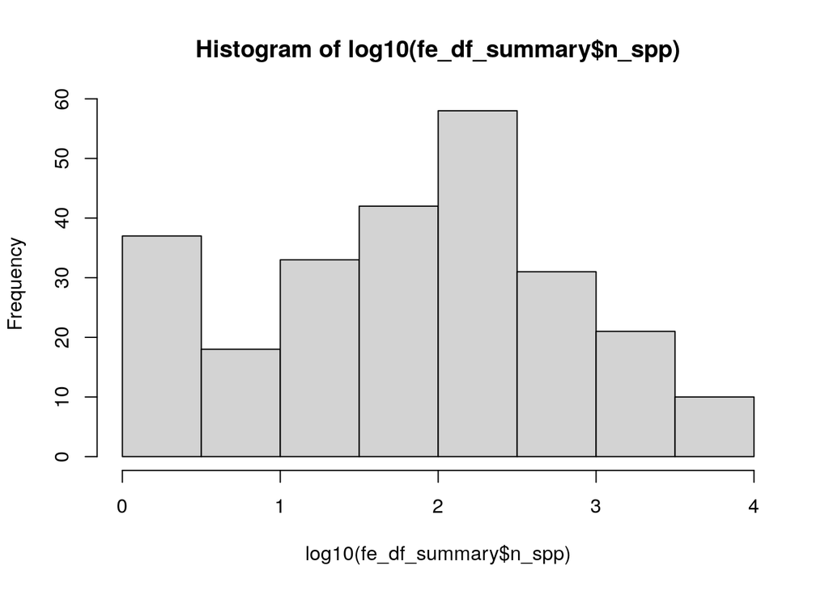

```r
fe_df_summary <- fe_df %>%
  group_by(fe_code) %>%
  summarize(n_spp = n_distinct(species))

hist(log10(fe_df_summary$n_spp))
```

```r
DT::datatable(fe_df_summary)
```

|  | fe_code | n_spp |
| --- | --- | --- |
| 1 | MOBsed_TRPter_LENvsm_WCOLben | 6848 |
| 2 | MOBses_TRPter_LENvsm_WCOLben | 6271 |
| 3 | MOBses_TRPter_LENsm_WCOLben | 5841 |
| 4 | MOBmob_TRPsec_LENvsm_WCOLben | 5683 |
| 5 | MOBsed_TRPter_LENsm_WCOLben | 4610 |
| 6 | MOBmob_TRPter_LENlg_WCOLben | 4169 |
| 7 | MOBmob_TRPter_LENsm_WCOLben | 3803 |
| 8 | MOBsed_TRPter_LENmed_WCOLben | 3795 |
| 9 | MOBmob_TRPter_LENvsm_WCOLben | 3768 |
| 10 | MOBmig_TRPsec_LENvsm_WCOLben | 3552 |

[output cut: 240 more lines]

```r
n_distinct(fe_df$fe_code)
```

```
## [1] 250
```

## 3.3 Write out functional entities

```r
fe_out_df <- fe_df %>%
  select(species, fe_code, n_spp = n) %>%
  mutate(fe_id = as.integer(fe_code))

write_csv(fe_out_df, here('_output/func_entities/fe_species.csv'))

fe_traits_df <- fe_df %>%
  select(fe_code, n_spp = n, mob, # fec, gen,
         trp, len, wcol) %>%
  distinct()

write_csv(fe_traits_df, here('_output/func_entities/fe_trait_codes.csv'))
```

## 3.4 Examine inclusion across Functional Entities, AquaMaps, and Species Vulnerability

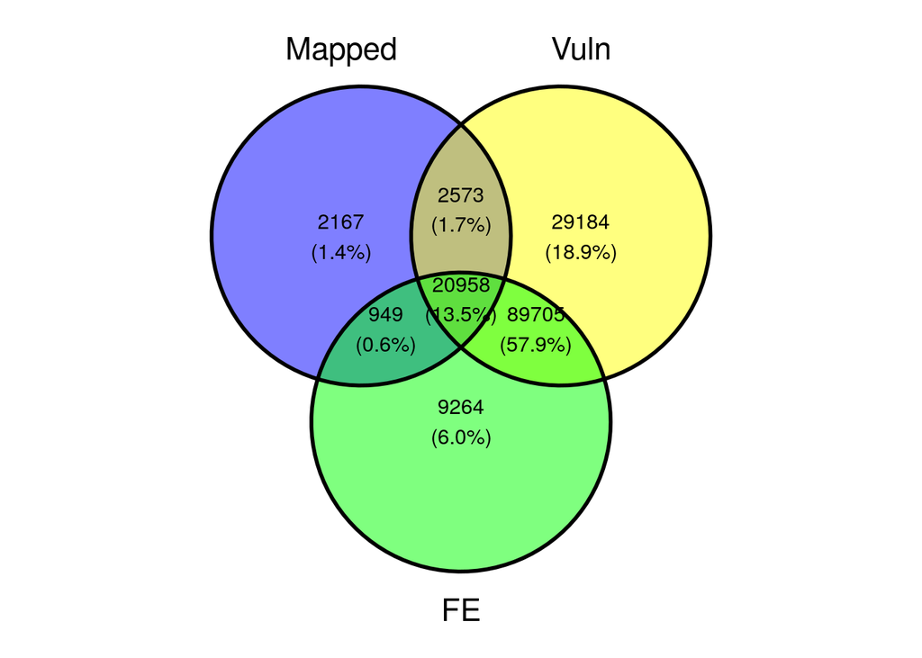

```r
library(ggvenn)
iucn_maps <- read_csv(here('_data/iucn_spp/spp_marine_maps_2021-3.csv'))
iucn_spp <- read_csv(here('_data/iucn_spp/iucn_to_worms_match.csv')) %>%
  filter(iucn_sid %in% iucn_maps$iucn_sid) %>%
  .$sciname %>% unique()
am_spp <- get_am_spp_info() %>%
  filter(occur_cells >= 10) %>%
  filter(!is.na(sciname)) %>%
  .$sciname %>% unique()

mapped_spp <- c(am_spp, iucn_spp) %>% unique()

vuln_spp <- get_spp_vuln() %>%
  .$species %>% unique()
fe_spp <- fe_out_df$species %>%
  unique()

x = list(Mapped = mapped_spp,
         Vuln   = vuln_spp,
         FE     = fe_spp)
ggvenn(x)
```